# MiCM: 03 - Quality Control

Ariel Madrigal Aguirre

2023-10-25

This workshop will guide you through the basics of ChIP-seq analysis with hands-on exercises. You will learn how to process ChIP-seq data: perform read alignment, peak calling, quality control, visualization through the genome browser, motif finding and gene set enrichment analysis.

In this tutorial, we are going to focus on quality control.

**Note**: All the code in this tutorial will be performed in R. You can follow up by typing R in your terminal or in Rstudio.

For this tutorial, we are going to use the R library ChIPQC

```r
library(ChIPQC)
library(TxDb.Hsapiens.UCSC.hg38.knownGene)
# You can install R libraries  with the following lines:
# if (!require("BiocManager", quietly = TRUE))
#    install.packages("BiocManager")
# BiocManager::install("ChIPQC")
# BiocManager::install("TxDb.Hsapiens.UCSC.hg38.knownGene")
```

You can find the manual in [here](https://bioconductor.org/packages/release/bioc/vignettes/ChIPQC/inst/doc/ChIPQC.pdf).

## 01 - Reading data

Let’s move to the scripts directory (or stay here if already there):

```r
setwd("chip_seq/scripts")
```

We’ve already prepared the sample sheet needed by ChIPQC. You can read it like this

```r
df<- read.table("../data/qc/qc.tsv", header=T)
df
```

| SampleID | Tissue | Factor | Condition | Treatment | Replicate | bamReads | ControlID | bamControl | Peaks | PeakCaller |
| --- | --- | --- | --- | --- | --- | --- | --- | --- | --- | --- |
| HIF1a_Rep1 | RCC4 | HIF1a | Normoxia | None | 1 | ../data/HIF1a_Rep1/HIF1a_Rep1.sorted.rmdup.bam | Input_Rep1 | ../data/Input_Rep1/Input_Rep1.sorted.rmdup.bam | ../data/HIF1a_Rep1/HIF1a_rep1_peaks.bed | bed |
| HIF1a_Rep2 | RCC4 | HIF1a | Normoxia | None | 2 | ../data/HIF1a_Rep2/HIF1a_Rep2.sorted.rmdup.bam | Input_Rep1 | ../data/Input_Rep1/Input_Rep1.sorted.rmdup.bam | ../data/HIF1a_Rep2/macs2/HIF1a_rep2_peaks.bed | bed |

Then, we construct the ChIPQC Experiment object

```r
chip<- ChIPQC(df, annotation="hg38")
```

```
HIF1a_Rep1 RCC4 HIF1a Normoxia None 1 bed
```

```
HIF1a_Rep2 RCC4 HIF1a Normoxia None 2 bed
```

```
Checking chromosomes:
```

```
[1] "chr6"
```

```
Compiling annotation...
```

```
Computing metrics for 3 samples...
```

```
Executing in parallel - max 6 cores.
```

## 02 - Summary of QCs

Let’s visualize the results

```r
chip
```

```
Samples: 3 : HIF1a_Rep1 HIF1a_Rep2 Input_Rep1
           Tissue Factor Condition Treatment    Control Replicate Peaks
HIF1a_Rep1   RCC4  HIF1a  Normoxia      None Input_Rep1         1    22
HIF1a_Rep2   RCC4  HIF1a  Normoxia      None Input_Rep1         2    28
            Reads Map% Filt% Dup% ReadL FragL RelCC  SSD RiP%
HIF1a_Rep1 192884  100     0    0    75   242  6.73 1.44 3.12
HIF1a_Rep2 213500  100     0    0    75   241  7.95 1.29 2.05
Input_Rep1 334415  100     0    0    75   183  7.37 1.40   NA
```

**FragL** This is the estimated mean fragment length that is calculated from the data by systematically shifting the reads on each strand towards each other until the highest degree of cross-coverage is obtained.

**RelCC** RelCC is a metric of ChIP-enrichment. It is calculated by comparing the maximal cross coverage peak (at the shift size corresponding to the fragment length) to the cross coverage at a shift size corresponding to the read length. Generally a value of 1 or greater is recommended.

**RiP%** RiP stands for percentage of reads in peaks, also known as FRIP. This is again an indicator of good enrichments. ChIPs around 1% or higher usually indicate successful enrichment.

**SSD** SSD is another metric of ChIP-enrichment. It is looking at the density of positions with different pileup values. The higher the value the more successful the ChIP was. SSD values close to 1 are generally correlated of poorly enriched samples, while successful ChIPs can expect values around 1.5, with highly enriched samples having SSD values of 2 or higher. It is computed by looking at the standard deviation of signal pile-up along the genome normalised to the total number of reads. An enriched sample typically has regions of significant pile-up so a higher SSD is more indicative of better enrichment. SSD scores are dependent on the degree of total genome wide signal pile-up and so are sensitive to regions of high signal found with Blacklisted regions as well as genuine ChIP enrichment.

## 03 - Cross-correlation

We can plot the cross-correlation profile:

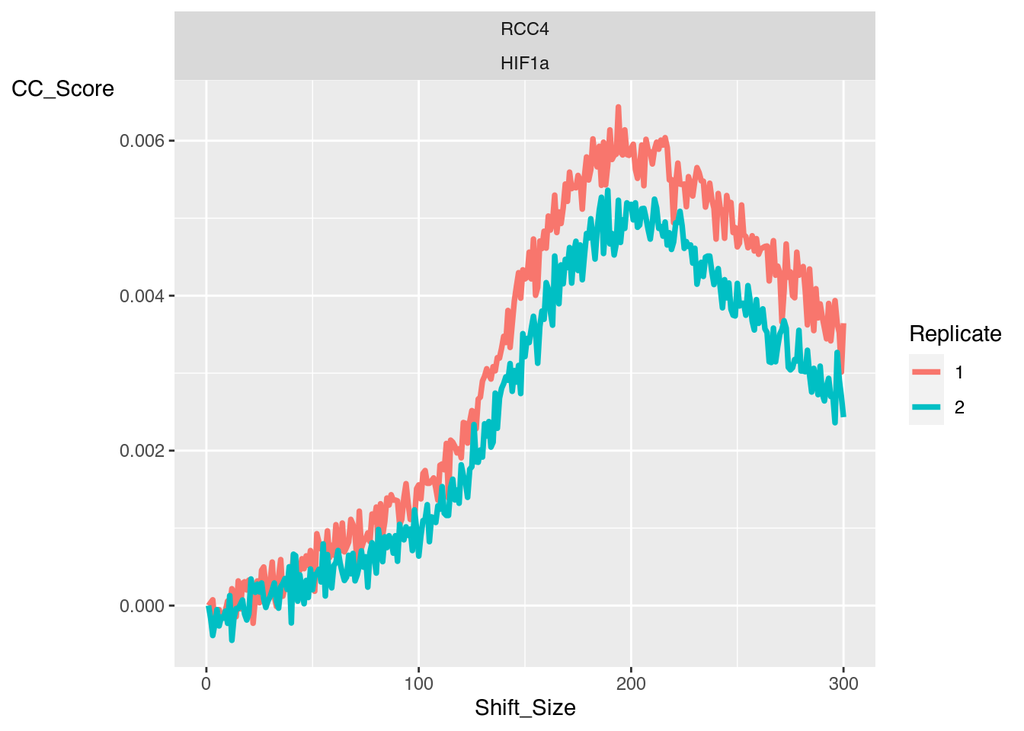

```r
plotCC(chip)
```

We don’t observe easily the ‘phantom-peak’, but there seems to be enrichment around the fragment length, which might indicate that these samples are of good quality.

We can plot other QCs associated with this sample.

## 04 - Enrichment in genomic intervals

A heatmap plot showing relative enrichment of reads around annotated genomic features.

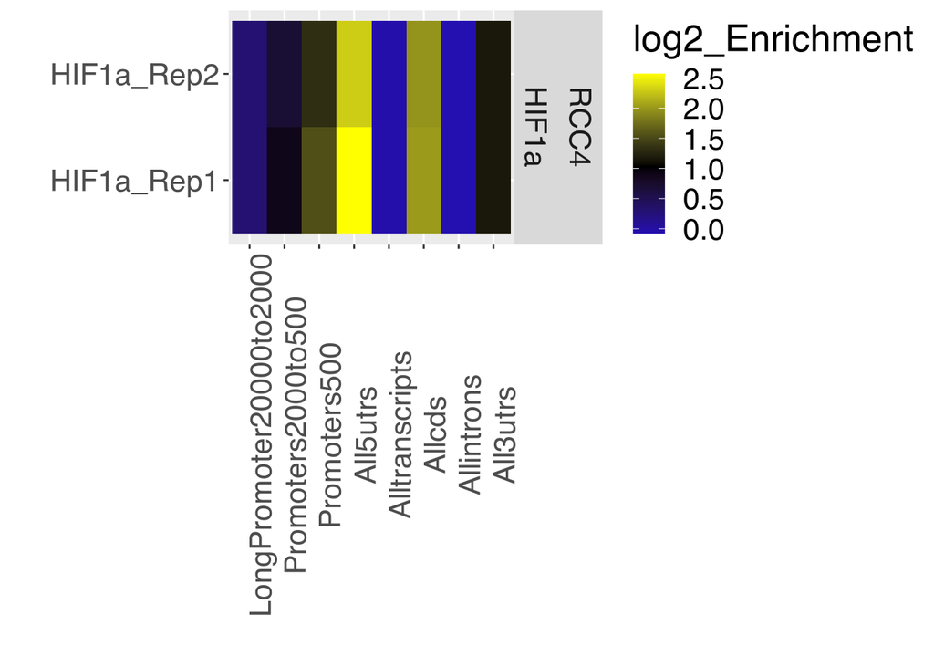

```r
plotRegi(chip)
```

## 05 - Peak profiles

Eeach peak is centered on its summit (point of highest pileup after extending the reads to the calculated fragment length), and the pileup values at bases in a window upstream and downstream of the summits is computed and averaged for all peaks in the sample. Good ChIPs will show distinctive patterns of enrichment in these peaks, while associated controls will be relatively flat.

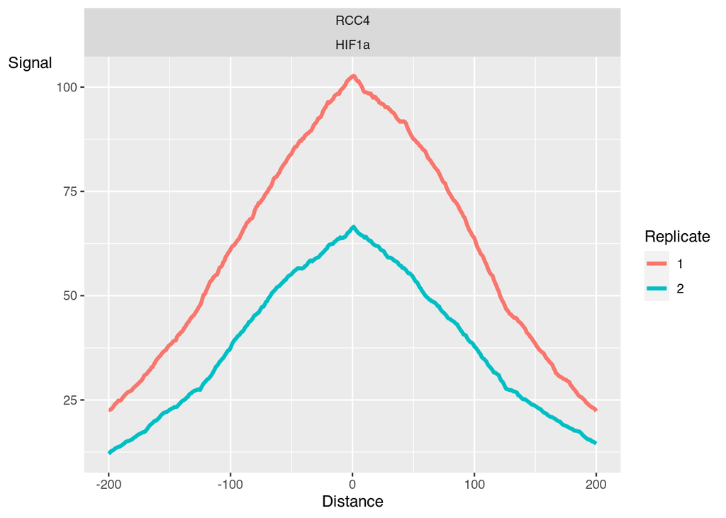

```r
plotPeakProfile(chip)
```

## 06 - Plotting sample clustering

### Correlation heatmap

The correlation heatmap is based on correlation values for all the peak scores for each sample.

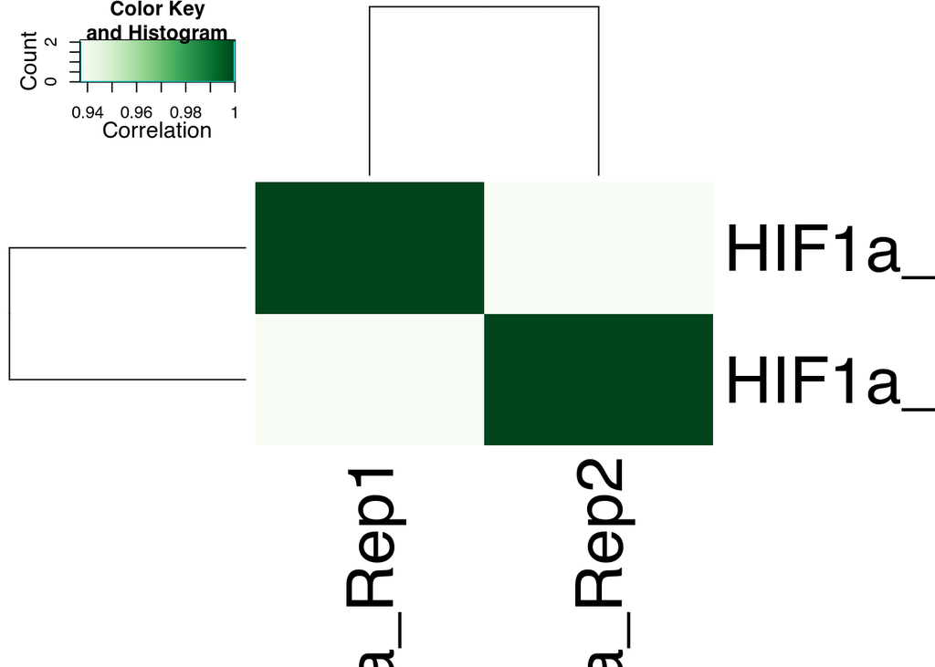

```r
plotCorHeatmap(chip)
```

### PCA

Compute a PCA based on all the peak scores for each sample.

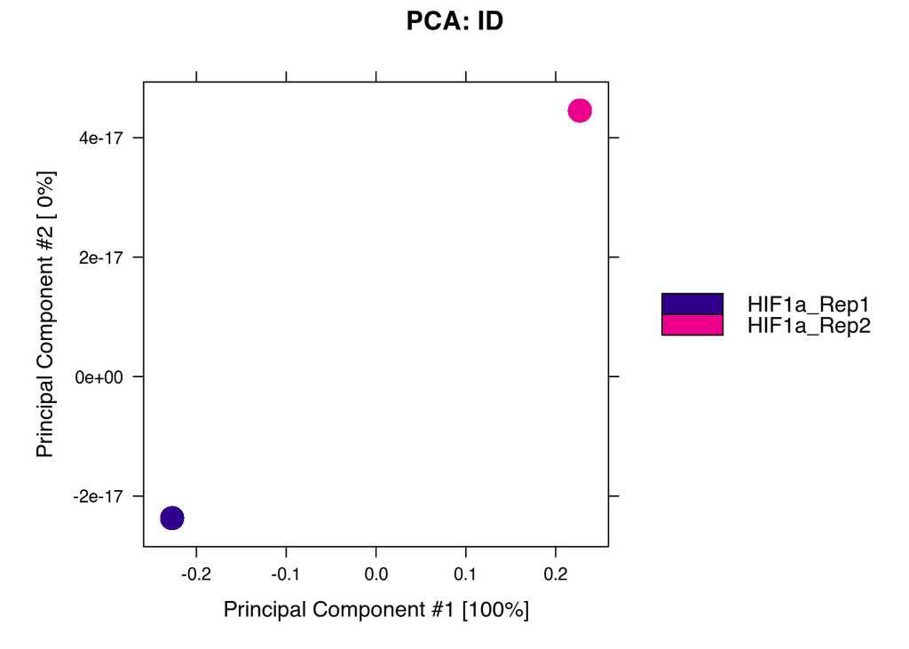

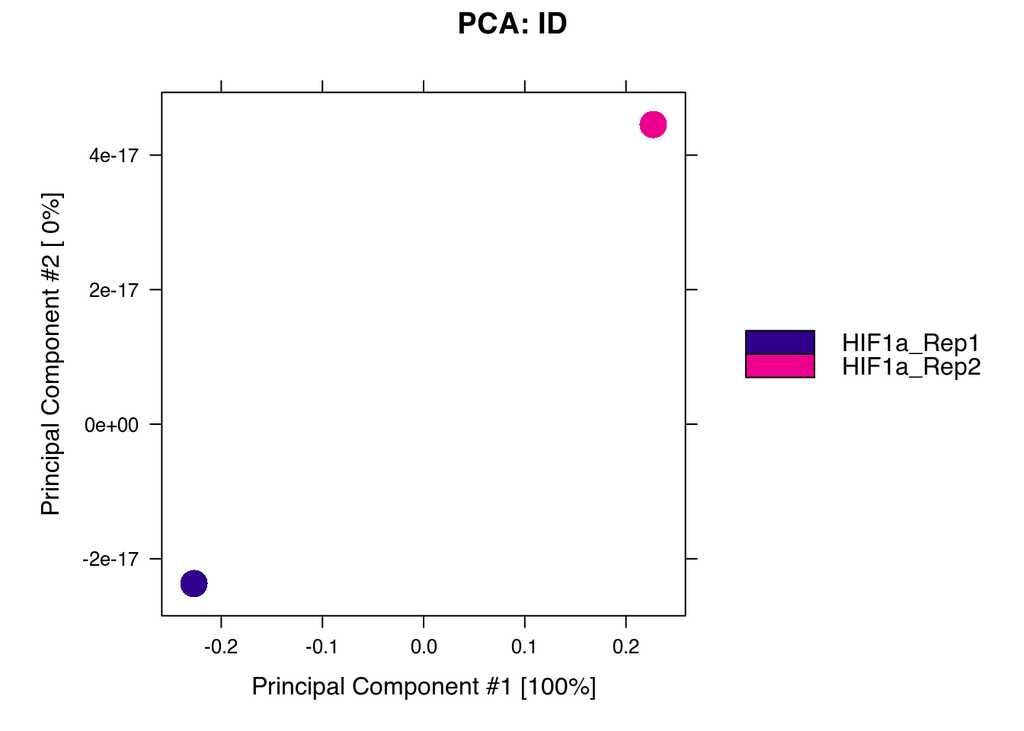

```r
plotPrincomp(chip)
```

## 07 - Exercises

- 1. Add the data for HIF2a into the QC. The data needed can be found in the chip_seq/data folder.

```bash
ls ../data/HIF2a_Rep1/
```

```
HIF2a_Rep1.sorted.rmdup.bam
HIF2a_Rep1.sorted.rmdup.bam.bai
macs2
```

```bash
ls ../data/HIF2a_Rep2/
```

```
HIF2a_Rep2.sorted.rmdup.bam
HIF2a_Rep2.sorted.rmdup.bam.bai
macs2
```